# Bank Marketing

Joshua Williams

July 1, 2017

## Import dependencies

```r
library(ResourceSelection)
```

```
## ResourceSelection 0.3-2   2017-02-28
```

```r
library(h2o)
```

## Read in the data

The data was donated in 2012 to UCI by a portuguese bank. It in most likely BPI given the size of the company.

```r
bank = read.table("C:/Users/willi/Desktop/bank-additional/bank-additional/bank-additional-full.csv", sep=";",header=T)
```

Input variables: ###bank client data: 1 - age (numeric) 2 - job : type of job (categorical: ‘admin.’,‘blue-collar’,‘entrepreneur’,‘housemaid’,‘management’,‘retired’,‘self-employed’,‘services’,‘student’,‘technician’,‘unemployed’,‘unknown’) 3 - marital : marital status (categorical: ‘divorced’,‘married’,‘single’,‘unknown’; note: ‘divorced’ means divorced or widowed) 4 - education (categorical: ‘basic.4y’,‘basic.6y’,‘basic.9y’,‘high.school’,‘illiterate’,‘professional.course’,‘university.degree’,‘unknown’) 5 - default: has credit in default? (categorical: ‘no’,‘yes’,‘unknown’) 6 - housing: has housing loan? (categorical: ‘no’,‘yes’,‘unknown’) 7 - loan: has personal loan? (categorical: ‘no’,‘yes’,‘unknown’) ###related with the last contact of the current campaign: 8 - contact: contact communication type (categorical: ‘cellular’,‘telephone’) 9 - month: last contact month of year (categorical: ‘jan’, ‘feb’, ‘mar’, …, ‘nov’, ‘dec’) 10 - day_of_week: last contact day of the week (categorical: ‘mon’,‘tue’,‘wed’,‘thu’,‘fri’) 11 - duration: last contact duration, in seconds (numeric). Important note: this attribute highly affects the output target (e.g., if duration=0 then y=‘no’). Yet, the duration is not known before a call is performed. Also, after the end of the call y is obviously known. Thus, this input should only be included for benchmark purposes and should be discarded if the intention is to have a realistic predictive model. ###other attributes: 12 - campaign: number of contacts performed during this campaign and for this client (numeric, includes last contact) 13 - pdays: number of days that passed by after the client was last contacted from a previous campaign (numeric; 999 means client was not previously contacted) 14 - previous: number of contacts performed before this campaign and for this client (numeric) 15 - poutcome: outcome of the previous marketing campaign (categorical: ‘failure’,‘nonexistent’,‘success’) ###social and economic context attributes 16 - emp.var.rate: employment variation rate - quarterly indicator (numeric) 17 - cons.price.idx: consumer price index - monthly indicator (numeric) 18 - cons.conf.idx: consumer confidence index - monthly indicator (numeric) 19 - euribor3m: euribor 3 month rate - daily indicator (numeric) 20 - nr.employed: number of employees - quarterly indicator (numeric)

Output variable (desired target): 21 - y - has the client subscribed a term deposit? (binary: ‘yes’,‘no’)

```r
str(bank)
```

```
## 'data.frame':    41188 obs. of  21 variables:
##  $ age           : int  56 57 37 40 56 45 59 41 24 25 ...
##  $ job           : Factor w/ 12 levels "admin.","blue-collar",..: 4 8 8 1 8 8 1 2 10 8 ...
##  $ marital       : Factor w/ 4 levels "divorced","married",..: 2 2 2 2 2 2 2 2 3 3 ...
##  $ education     : Factor w/ 8 levels "basic.4y","basic.6y",..: 1 4 4 2 4 3 6 8 6 4 ...
##  $ default       : Factor w/ 3 levels "no","unknown",..: 1 2 1 1 1 2 1 2 1 1 ...
##  $ housing       : Factor w/ 3 levels "no","unknown",..: 1 1 3 1 1 1 1 1 3 3 ...
##  $ loan          : Factor w/ 3 levels "no","unknown",..: 1 1 1 1 3 1 1 1 1 1 ...
##  $ contact       : Factor w/ 2 levels "cellular","telephone": 2 2 2 2 2 2 2 2 2 2 ...
##  $ month         : Factor w/ 10 levels "apr","aug","dec",..: 7 7 7 7 7 7 7 7 7 7 ...
##  $ day_of_week   : Factor w/ 5 levels "fri","mon","thu",..: 2 2 2 2 2 2 2 2 2 2 ...
##  $ duration      : int  261 149 226 151 307 198 139 217 380 50 ...
##  $ campaign      : int  1 1 1 1 1 1 1 1 1 1 ...
##  $ pdays         : int  999 999 999 999 999 999 999 999 999 999 ...
##  $ previous      : int  0 0 0 0 0 0 0 0 0 0 ...
##  $ poutcome      : Factor w/ 3 levels "failure","nonexistent",..: 2 2 2 2 2 2 2 2 2 2 ...
##  $ emp.var.rate  : num  1.1 1.1 1.1 1.1 1.1 1.1 1.1 1.1 1.1 1.1 ...
##  $ cons.price.idx: num  94 94 94 94 94 ...
##  $ cons.conf.idx : num  -36.4 -36.4 -36.4 -36.4 -36.4 -36.4 -36.4 -36.4 -36.4 -36.4 ...
##  $ euribor3m     : num  4.86 4.86 4.86 4.86 4.86 ...
##  $ nr.employed   : num  5191 5191 5191 5191 5191 ...
##  $ y             : Factor w/ 2 levels "no","yes": 1 1 1 1 1 1 1 1 1 1 ...
```

### Data Cleaning

As mentioned above the duration is a very good predictor, but not important considering our business question. It is intuitive that if a call only last a few seconds there was probably no sale made. If a call last longer a sale is more likely to have been made, becuase more time is available to awnser the customers concerns before they invest.

```r
table(bank[which(bank$duration < 38),]$y)
```

```
##
##   no  yes
## 2161    1
```

There would be no way to know the duration of the call before the call is made. The calls made with less than 4 seconds are deleted.

```r
rows=row.names(bank[which(bank$duration < 4),])
rows=as.integer(rows)
bank = bank[-rows,]
dim(bank)
```

```
## [1] 41177    21
```

Duration is not used becuase it is not known how long a phone call will last before it is made. The month and day of the week columns are also deleted, because they are irelevant to the business question on hand.

```r
bank$duration = NULL
bank$month=NULL
bank$day_of_week=NULL
```

Normalize the data.

```r
norm= function(x){
  return((x-min(x))/ (max(x)- min(x)))}

for (i in 1:dim(bank)[2]){ bank[,i]=as.numeric(bank[,i])}

banknorm= data.frame((lapply(bank[,1:(dim(bank)[2]-1)], norm)))
banknorm$y= bank$y
```

### Data Exploratoion

It appears there is some correlation of between the social economic factors.

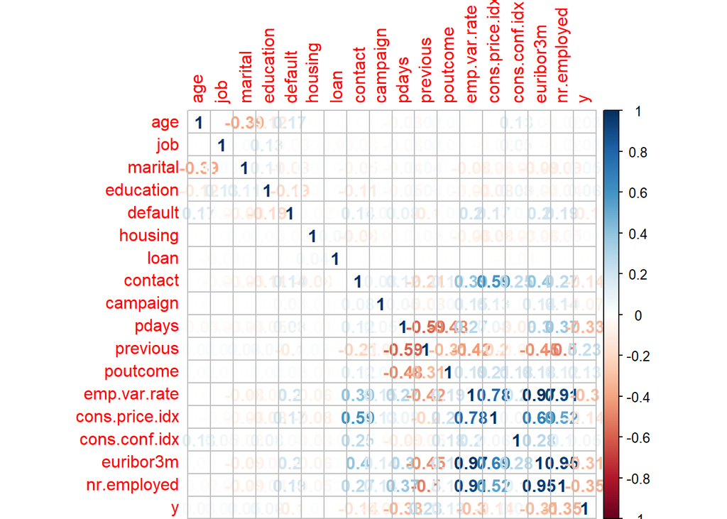

```r
corrplot::corrplot(stats::cor(banknorm),method="number")
```

Bank Client Data and Predictor

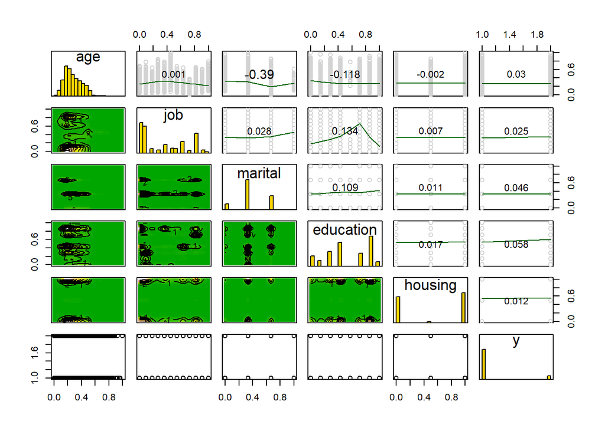

```r
ResourceSelection::kdepairs(banknorm[,c(1,2,3,4,6,18)])
```

```r
stats::cor(banknorm)[c(5,7),]
```

```
##                  age         job      marital    education      default
## default  0.165084462 -0.02831552 -0.079479065 -0.186907073  1.000000000
## loan    -0.007243217 -0.01027084  0.005701209  0.006342337 -0.003775903
##             housing         loan     contact    campaign       pdays
## default -0.01583997 -0.003775903  0.13531570 0.032828374 0.080050914
## loan     0.04443482  1.000000000 -0.00869076 0.005193458 0.000284364
##             previous     poutcome emp.var.rate cons.price.idx
## default -0.102412618  0.023449178  0.203267261    0.168110344
## loan    -0.001234678 -0.001514108  0.001743325   -0.002513643
##         cons.conf.idx     euribor3m nr.employed            y
## default    0.02654366  1.953350e-01 0.189824385 -0.099405872
## loan      -0.01213170 -3.673124e-06 0.003795572 -0.004904659
```

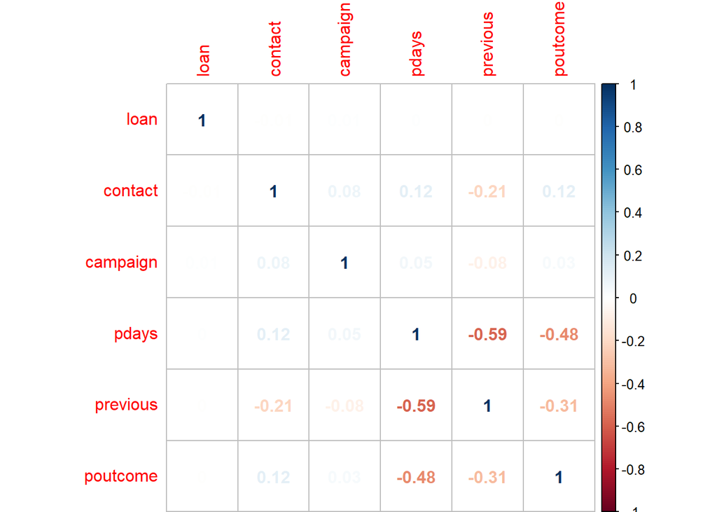

```r
corrplot::corrplot(stats::cor(banknorm[7:12]),method="number")
```

There appears to be some multicollinearity between the social and economic factors.

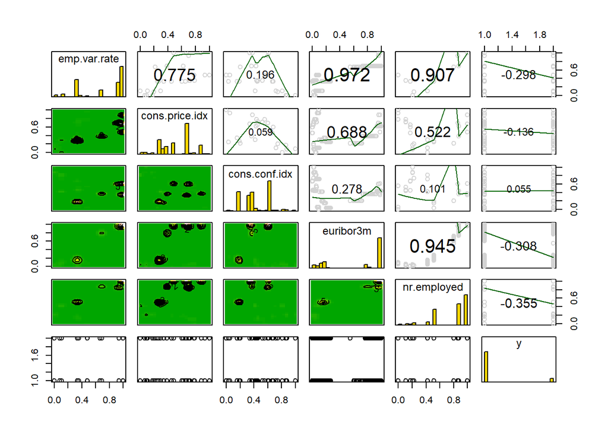

```r
ResourceSelection::kdepairs(banknorm[13:18])
```

```r
pcse= princomp(banknorm[13:17])
summary(pcse)
```

```
## Importance of components:
##                           Comp.1     Comp.2     Comp.3      Comp.4
## Standard deviation     0.5946353 0.19558546 0.17133023 0.048037426
## Proportion of Variance 0.8325420 0.09006953 0.06911508 0.005433307
## Cumulative Proportion  0.8325420 0.92261150 0.99172658 0.997159888
##                             Comp.5
## Standard deviation     0.034730843
## Proportion of Variance 0.002840112
## Cumulative Proportion  1.000000000
```

```r
Socio_Economic = pcse$scores[,1:2] #92% cumulative variennce
#remove old socio economic
banknorm[13:17]=NULL
banknorm$SEC1=Socio_Economic[,1]
banknorm$SEC2=Socio_Economic[,2]
```

The correlation plot shows that the priciple components fixed the multicollinearity.

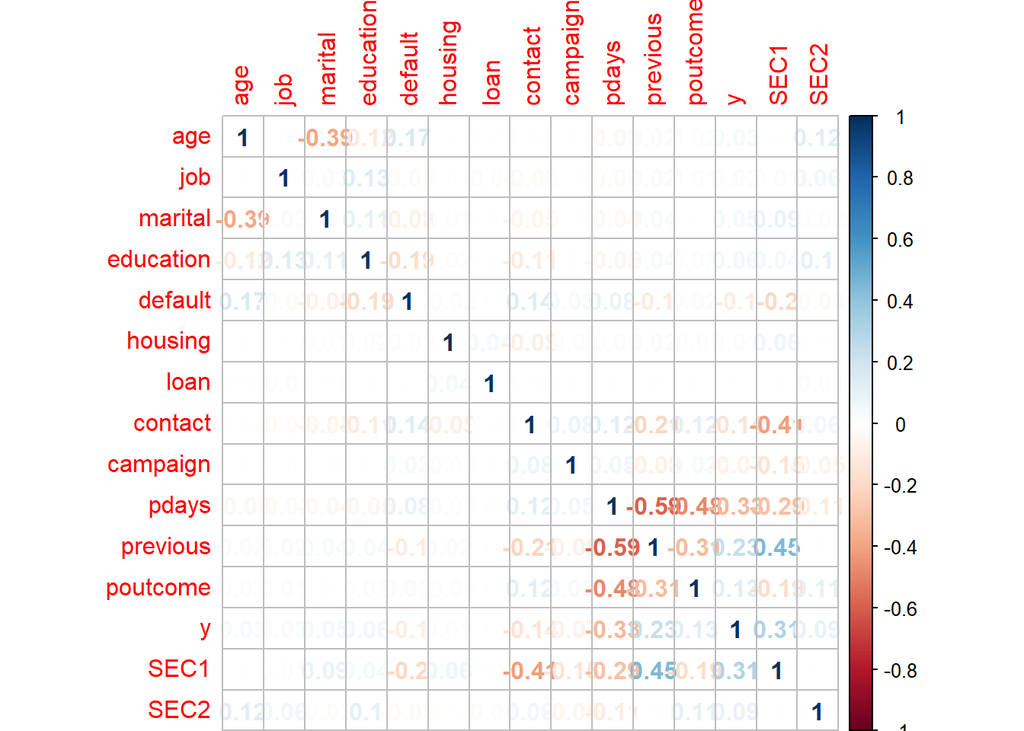

```r
corrplot::corrplot(stats::cor(banknorm),method="number")
```

Return y to factor so Neural net can output probability with softmax.

```r
banknorm$y=as.factor(banknorm$y)
```

Split the data into train and test.

```r
idx = sample(1:nrow(banknorm), 0.7*nrow(banknorm))

train=banknorm[idx,]
test=banknorm[-idx,]
dim(test)
```

```
## [1] 12354    15
```

```r
dim(train)
```

```
## [1] 28823    15
```

```r
h2o.init()
```

```
##
## H2O is not running yet, starting it now...
```

[output not shown]

```r
x.hex = as.h2o(train)
test.hex = as.h2o(test)
deep = h2o.deeplearning(training_frame=x.hex,
                 x=c(1:12,14,15),
                 y=13,
                 epochs = 10,
                 activation="Rectifier",
                 hidden=c(10,10),
                 rate = .03,
                 adaptive_rate = T,
                 nesterov_accelerated_gradient = T,
                 initial_weight_distribution = "UniformAdaptive")
```

Predict the test data.

```r
pred= predict(deep, test.hex)
```

The AUC Curve is plotted below. As seen the model has a decent performance.

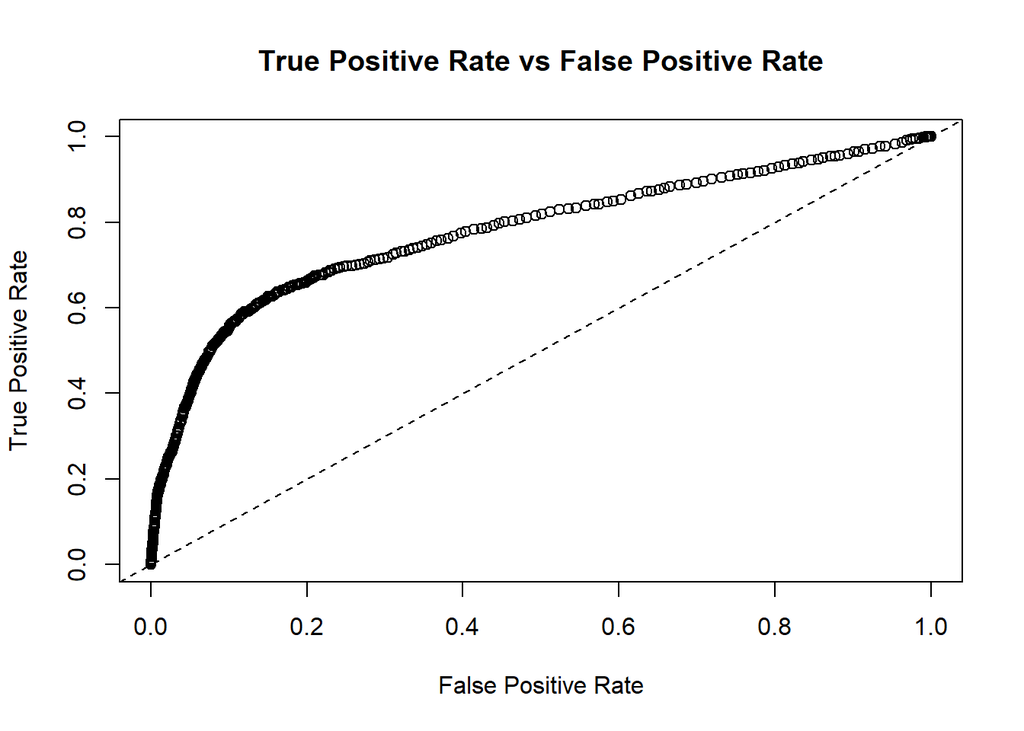

```r
perf = h2o.performance(deep, test.hex)
plot(perf)
```

```r
perf
```

```
## H2OBinomialMetrics: deeplearning
##
## MSE:  0.08145917
## RMSE:  0.2854105
## LogLoss:  0.289054
## Mean Per-Class Error:  0.2840822
## AUC:  0.7775926
## Gini:  0.5551851
##
## Confusion Matrix (vertical: actual; across: predicted) for F1-optimal threshold:
##            1    2    Error         Rate
## 1      10100  866 0.078971   =866/10966
## 2        679  709 0.489193    =679/1388
## Totals 10779 1575 0.125061  =1545/12354
##
## Maximum Metrics: Maximum metrics at their respective thresholds
##                         metric threshold    value idx
## 1                       max f1  0.163711 0.478569 215
## 2                       max f2  0.104354 0.538014 262
## 3                 max f0point5  0.218526 0.479717 187
## 4                 max accuracy  0.606315 0.898656  77
## 5                max precision  0.958384 1.000000   0
## 6                   max recall  0.005959 1.000000 396
## 7              max specificity  0.958384 1.000000   0
## 8             max absolute_mcc  0.163711 0.408891 215
## 9   max min_per_class_accuracy  0.060740 0.711816 308
## 10 max mean_per_class_accuracy  0.104354 0.737580 262
##
## Gains/Lift Table: Extract with `h2o.gainsLift(<model>, <data>)` or `h2o.gainsLift(<model>, valid=<T/F>, xval=<T/F>)`
```

The original data will be used with the same index as test in order to see the data without normilazation.It appears the model ouput The people most likely to buy are: age: 42 job: Admin, then Blue collar Marital: Married Education: University Degree Default: NO loan : NO conatct: Cellular Number of contact performed: 1 Number of days passed before client was previously contacted: 999 poutcome: nonexistent

```r
testdenorm=bank[-idx,]
testdenorm$pred=as.data.frame(pred)$predict
test$pred=as.data.frame(pred)$predict
yes=dplyr::filter(testdenorm, pred==2)
mean(yes$age)
```

```
## [1] 41.80574
```

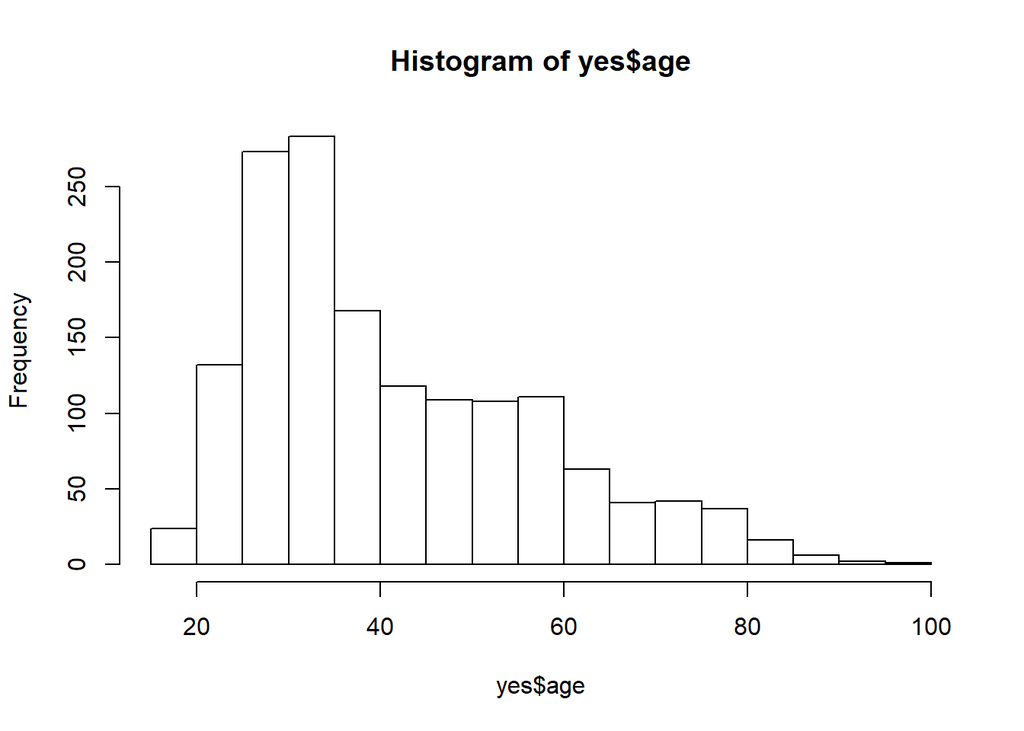

```r
hist(yes$age)
```

```r
nb = h2o.naiveBayes(training_frame=x.hex,
                 x=c(1:12,14,15),
                 y=13)
```

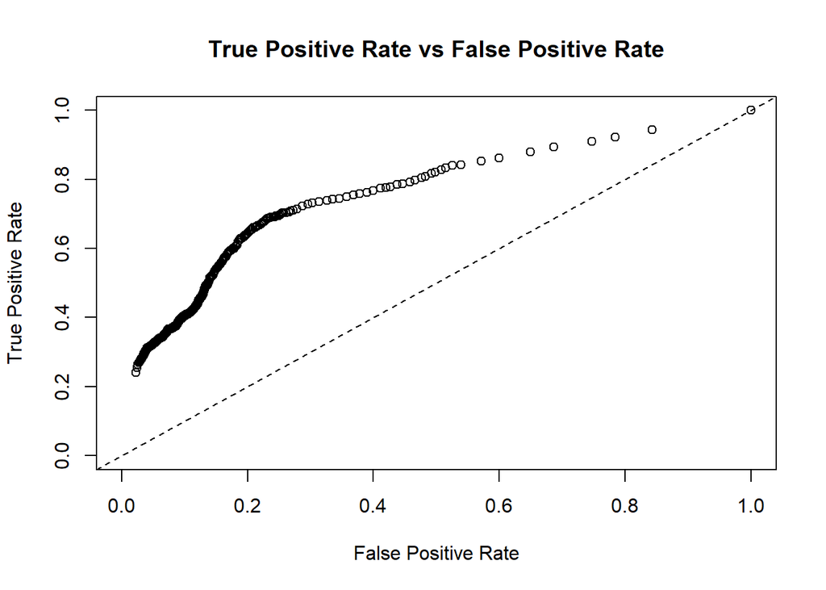

```r
perfnb = h2o.performance(nb, test.hex)
plot(perfnb)
```

```r
perfnb
```

```
## H2OBinomialMetrics: naivebayes
##
## MSE:  0.1282856
## RMSE:  0.3581698
## LogLoss:  1.007566
## Mean Per-Class Error:  0.2800336
## AUC:  0.7616609
## Gini:  0.5233218
##
## Confusion Matrix (vertical: actual; across: predicted) for F1-optimal threshold:
##           1    2    Error         Rate
## 1      8901 2065 0.188309  =2065/10966
## 2       516  872 0.371758    =516/1388
## Totals 9417 2937 0.208920  =2581/12354
##
## Maximum Metrics: Maximum metrics at their respective thresholds
##                         metric threshold    value idx
## 1                       max f1  0.056910 0.403237 325
## 2                       max f2  0.035696 0.526287 345
## 3                 max f0point5  0.995774 0.459669   2
## 4                 max accuracy  0.999966 0.894852   0
## 5                max precision  0.999966 0.577123   0
## 6                   max recall  0.000043 1.000000 399
## 7              max specificity  0.999966 0.977749   0
## 8             max absolute_mcc  0.995774 0.337123   2
## 9   max min_per_class_accuracy  0.016081 0.714697 364
## 10 max mean_per_class_accuracy  0.035696 0.727132 345
##
## Gains/Lift Table: Extract with `h2o.gainsLift(<model>, <data>)` or `h2o.gainsLift(<model>, valid=<T/F>, xval=<T/F>)`
```

```r
percent_yes = table(bank$y)[[2]]/dim(bank)[1]
print(paste("percent of people who say yes", percent_yes))
```

```
## [1] "percent of people who say yes 0.112684265488015"
```

```r
bank = read.table("C:/Users/willi/Desktop/bank-additional/bank-additional/bank-additional-full.csv", sep=";",header=T)
mean_duration = (mean(bank$duration)/60)+2
print(paste("Avg Duration of call in min plus two minutes for transition:" ,mean_duration))
```

```
## [1] "Avg Duration of call in min plus two minutes for transition: 6.30475016995241"
```

```r
hrl_rate=31.5
num_cust=1400000
```

In order to know how many customers to call a monte carlo simulation is run to capture customers that say yes from the .11 percent of the customers that actually say yes.

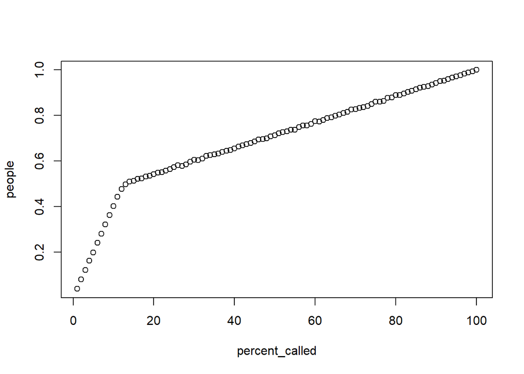

```r
percent_called=1:100
people =c() #pectent of the 11% of customers who will buy
for(q in 1:100){
#Monte Carlo Simulation
l=c()
for (i in 1:250){
samp = sample(1:(dim(test)[1]), 1000)
df=test[samp,]
table(test$y)[[2]]/table(test$y)[[1]]
df1=df[order(df$pred,decreasing = T),]
dfcall= df1[1:(1000*q/100),]
l=append(l,(table(dfcall$y)[[2]]/table(df$y)[[2]]))
}
people=append(people, mean(l))
}
da=data.frame(percent_called, people)
plot(da)
```

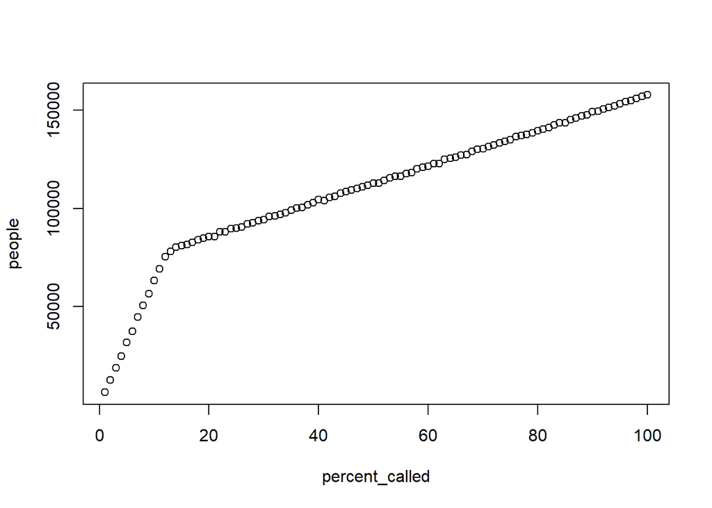

```r
#Same plot but with number of people on the yaxis rather than percent of percent.
percent_called=1:100
people =c() #pectent of the 11% of customers who will buy
for(q in 1:100){
#Monte Carlo Simulation
l=c()
for (i in 1:250){
samp = sample(1:(dim(test)[1]), 1000)
df=test[samp,]
table(test$y)[[2]]/table(test$y)[[1]]
df1=df[order(df$pred,decreasing = T),]
dfcall= df1[1:(1000*q/100),]
l=append(l,(table(dfcall$y)[[2]]/table(df$y)[[2]]))
}
people=append(people, ((mean(l)*0.1126542)*num_cust) )
}
da=data.frame(percent_called, people)
plot(da)
```

Final Simulation using 18 percent of customers.

```r
#Monte Carlo Simulation
l=c()
for (i in 1:1000){
samp = sample(1:(dim(test)[1]), 1000)
df=test[samp,]
table(test$y)[[2]]/table(test$y)[[1]]
df1=df[order(df$pred,decreasing = T),]
dfcall= df1[1:(1000*.18),]
l=append(l,(table(dfcall$y)[[2]]/table(df$y)[[2]]))
}


#cost without model
WM_cost_call=(num_cust/mean_duration)*hrl_rate

#cost with model
M_cost_call=((num_cust*.18)/mean_duration)*hrl_rate

#Savings
s=WM_cost_call-M_cost_call
s=formatC(s, format="d", big.mark=",")
lower = formatC(as.integer(((mean(l)-2*sd(l)))*(percent_yes*num_cust)), format="d", big.mark=",")
upper=formatC(as.integer((mean(l)+2*sd(l))*(percent_yes*num_cust)), format="d", big.mark=",")

#Certainty from monte carlo simulation
certainty= sum(l>(mean(l)-2*sd(l)) & l<(mean(l)+2*sd(l)))/length(l)

print(paste("Based on the simulation by calling 18% of the customers there is ",certainty*100,"%"," certainty that the model will get between ",lower," and " ,upper," customers saving $",s, sep=''))
```

```
## [1] "Based on the simulation by calling 18% of the customers there is 95.7% certainty that the model will get between 70,202 and 97,329 customers saving $5,735,675"
```